# Week 10: Modern Differences-in-Differences

PS 813 - Causal Inference

Anton Strezhnev

strezhnev@wisc.edu

University of Wisconsin-Madison

March 29, 2027

$$\require{cancel}$$

## Last week

- Differences-in-differences with **two groups**
  - 2x2 comparison: treated and control groups at post-treatment time $t$ vs. treated and control at some pre-treatment $t^\prime$
- Two approaches to estimation
  - **First-differences** regression
  - **Two-way fixed effects** regression (static and “dynamic”)
- Pre-trends placebos
  - Differences-in-differences in two pre-treatment periods.
  - **Not** proof that parallel trends hold but a useful diagnostic
  - Be careful of power here - **underpowered** tests may fail to reject even under sizeable violations!

## Review: Event study plots

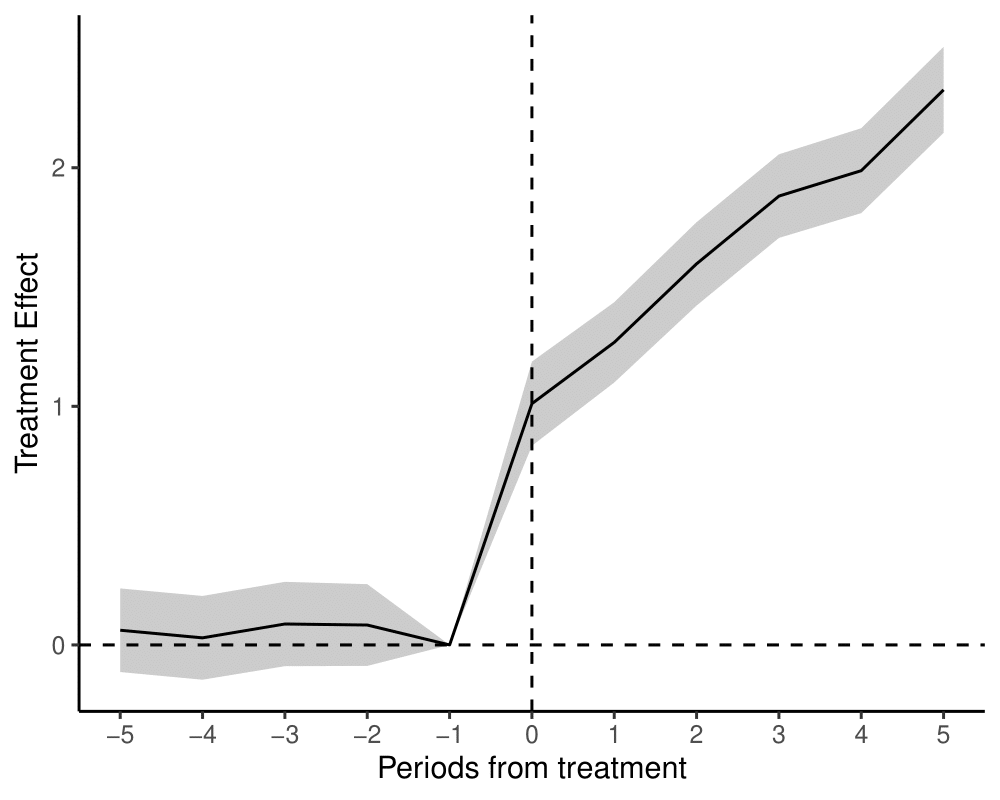

## This week

- Differences-in-differences under **varying treatment adoption**
  - **Staggered adoption** - Treatment is initiated by units at different time periods
  - **Treatment reversal** - Units that adopt treatment can later switch to control
- Problems
  - Conventional estimation strategies (esp. TWFE) require **additional assumptions** - constant treatment effects
  - Not feasible in many settings (e.g. persistent effects over time)
- Alternative estimators
  - Construct an estimator using **only** the “valid” 2x2 DiDs (no additional effect homogeneity assumptions)
  - Re-fit the TWFE regression or construct the correct “first-differences” regression.

## Difference-in-differences with staggered adoption

## Running Example: Paglayan (2019, AJPS)

> Paglayan, Agustina S. “Public‐sector unions and the size of government.” American Journal of Political Science 63, no. 1 (2019): 21-36.
- **Paglayan (2019)** examines whether the implementation of mandatory collective bargaining in some states affects state expenditures on education
  - Cross-sectionally, states with collective bargaining laws spend more on education
  - But is this just selection?
- **Design**: Look at the roll-out of collective bargaining laws over time in U.S. states
  - Eliminate the baseline differences in spending across states using a DiD approach.

```r
library(panelView)
union <- read_dta("assets/data/Paglayan Dataset.dta")
union <- union %>% filter(!is.na(studteachratio)&State !="DC"&State != "WI"&year>1959&year<1997)
table(union$YearCBrequired)
```

```
1965 1966 1968 1969 1970 1971 1972 1973 1974 1975 1976 1978 1984 1987
  74   74   74  148  222  111   37   37   74   74  111   37   74   37
```

## Staggered adoption

- Collective bargaining laws were rolled out in a *staggered* fashion

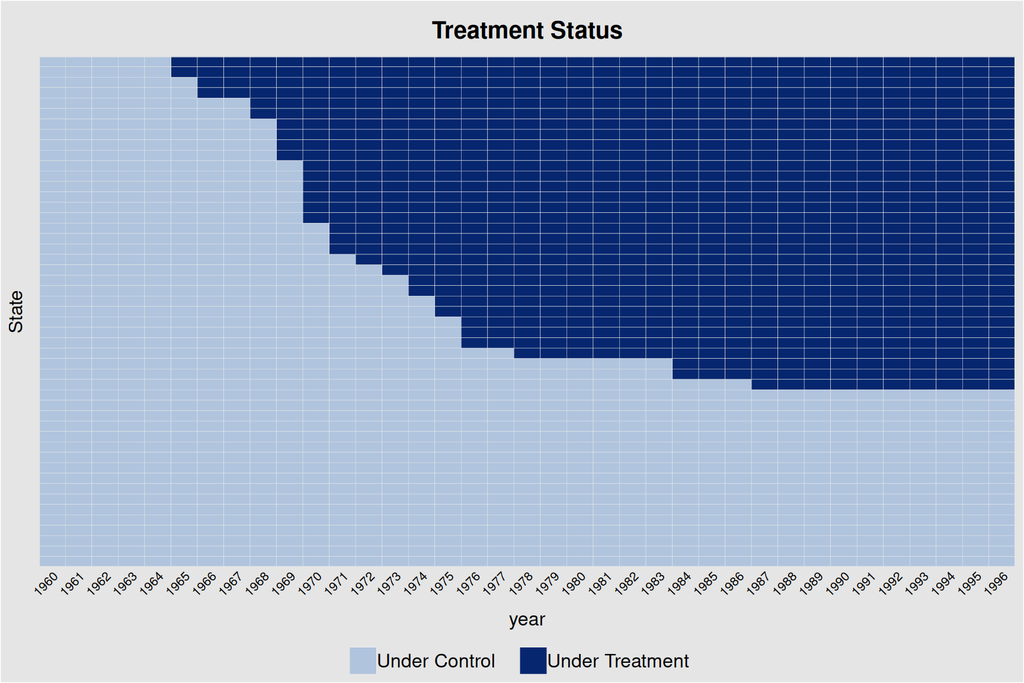

## DiD with staggered adoption

- We’ll extend our previous set-up with $T$ treated periods to **also** allow for varying treatment times
  - Let $G_i$ denote the **time period** when unit $i$ initiates treatment
- $\mathcal{G} \in \{2, 3, \dotsc, T, \infty\}$ denotes the set of possible **treatment timing groups**
  - We’ll use $G_i = \infty$ to denote the **never-treated** units
  - $N_{g}$ observations in each timing group $g$
- Define potential outcomes in terms of assignment to a **timing group**
  - $Y_{it}(g) = Y_{it}$ for units with $G_i = g$
  - We’ll denote $Y_{it}(\infty)$ as the “control” potential outcome

## DiD with staggered adoption

[figure not shown]

DiD with 4 periods, 3 timing groups

## DiD with staggered adoption

- Building block: **“Group-Time” ATT** (Callaway and Sant’anna)

  $$\text{ATT}_{g}(t) = E[Y_{it}(g) - Y_{it}(\infty) | G_i = g]$$
- What would have happened to group $g$ at time $t$ had it never received treatment
- **Assumption**: No reverse causality/anticipation

  $$Y_{it}(g) = Y_{it}(\infty) \forall t < g$$
- The potential outcomes among the “not-yet-treated” at time $t$ are the same as the “never-treated” at time $t$
- **Assumption**: “General” parallel trends. For all $t \neq t^{\prime}$ and $g \neq g^{\prime}$

  $$E[Y_{it}(\infty) - Y_{it^{\prime}}(\infty)| G_i = g] - E[Y_{it}(\infty) - Y_{it^{\prime}}(\infty)| G_i = g^{\prime}]$$
- Can weaken this
  - Only assume parallel trends with respect to the **ever-treated** units ($g \neq \infty$)

## DiD with staggered adoption

- Let $\bar{Y}_{g, t}$ denote the **average** outcome at time $t$ for timing group $g$

  $$\bar{Y}_{g, t} = \frac{1}{N_g} \sum_{i: G_i = g} Y_{it}$$
- Any **group-time ATT** can be consistently estimated by the 2x2 difference-in-difference with any $g^\prime > t$ and $t^\prime < g$

  $$\widehat{ATT}_g(t) = \bar{Y}_{g, t} - \bar{Y}_{g^\prime, t} - \bar{Y}_{g, t^\prime} + \bar{Y}_{g^\prime, t^\prime}$$
- We can **average** over the DiDs with all **not-yet-treated** units at time $t$

  $$\widehat{ATT}_g(t) = \bar{Y}_{g, t} - \sum_{g^\prime > t} \frac{N_{g^\prime}}{N^{(t)}}\bar{Y}_{g^\prime, t} - \bar{Y}_{g, t^\prime} + \sum_{g^\prime > t} \frac{N_{g^\prime}}{N^{(t)}}\bar{Y}_{g^\prime, t^\prime}$$

  where $N^{(t)} = \sum_{g^\prime > t} N_{g^\prime}$

## Visualizing group effects

[figure not shown]

DiD for group 3, time 3

## Visualizing group effects

[figure not shown]

DiD for group 3, time 4

## Visualizing group effects

[figure not shown]

DiD for group 4, time 4

## Visualizing group effects

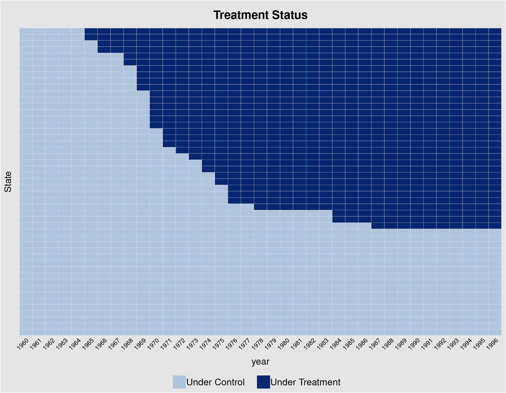

## Aggregating group-time ATTs

- It is unlikely that we can estimate each particular group-time ATT with much precision
  - And we’re probably more interested in some *overall* effect of treatment or an *average* of group-time ATTs.
- How should we aggregate?
  - Defining a single “post-treatment” average is tricky - multiple ways to aggregate
- Averaging **uniformly** within unit first - non-uniform weights on time.

  $$ATT = \frac{1}{N}\sum_{g = 2}^T \frac{N_{g}}{T-g -1}\sum_{t \ge g}^T ATT_{g}(t)$$
- Averaging **uniformly** within time first - non-uniform weights on units

  $$ATT = \frac{1}{T-1}\sum_{t=2}^{T} \sum_{g=2}^{t} \frac{N_g}{\sum_{g^\prime=2}^{t} N_{g^\prime}} ATT_{g}(t)$$

## Aggregating group-time ATTs

- “Relative-treatment-time” effects - average of all group-time ATTs where $t = g + q$

  $$RTT(q) = \sum_{g=\max(2,\, 1-q)}^{T - \max(0,\, q)} \frac{N_g}{\sum_{g^\prime=\max(2,\, 1-q)}^{T-\max(0,\, q)} N_{g^\prime}} ATT_g(g + q) \quad \text{for } q = -(T-1), \dotsc, T-2$$
- In staggered adoption, the **relative-treatment time** estimates for the earlier pre- and later post- periods will involve **different** sets of units!
  - Composition changes might mask parallel trends violations!

## Two-way FE w/ staggered adoption

- Does the **static** specification identify an average of group-time ATTs?

  $$Y_{it} = \alpha_i + \delta_{t} + \tau D_{it} + \epsilon_{it}$$
- No! **(Goodman-Bacon, 2021)**
  - $\hat{\tau}$ is a weighted average over 2x2 differences-in-differences.
  - Only **some** of those are valid under our identification assumptions
  - Others require an additional **constant effects** assumption in order to identify an ATT.
- Intuition:
  - The TWFE estimator under staggered adoption incorporates 2x2 DiD terms where the “baseline” period is in the **future** (where both units are under treatment)

## Two-way FE w/ staggered adoption

[figure not shown]

Good 2x2

## Two-way FE w/ staggered adoption

[figure not shown]

Bad 2x2

## Two-way FE w/ staggered adoption

- Consider the “forbidden comparison” with
  - $t^\prime > t$, (baseline period is in the “future”)
  - $g \le t < t^\prime$ (timing group of interest is treated prior to both periods).
  - $t < g^\prime \le t^\prime$, (comparison group is **treated** at the baseline period)
- The 2x2 difference-in-difference is:

  $$\bar{Y}_{g, t} - \bar{Y}_{g^\prime, t} - \bar{Y}_{g, t^\prime} + \bar{Y}_{g^\prime, t^\prime}$$
- Under parallel trends, this identifies

  $$ATT_{g}(t) - ATT_{g^\prime}(t) - ATT_{g}(t^\prime) + ATT_{g^\prime}(t^\prime)$$
- Under no anticipation, only $ATT_{g^\prime}(t)$ is zero.

## Two-way FE w/ staggered adoption

- We need to make an **effect homogeneity** assumption for this 2x2 to identify a single treatment effect.

  $$ATT_{g}(t) - ATT_{g}(t^\prime) + ATT_{g^\prime}(t^\prime)$$
- The first is to assume homogeneity **within unit** over time
  - $ATT_{g}(t) = ATT_{g}(t^\prime)$
- The second is to assume homogeneity **in calendar time**
  - $ATT_{g}(t^\prime) = ATT_{g^\prime}(t^\prime)$

## Two-way FE w/ staggered adoption

- What about the **dynamic** specification?

  $$Y_{it} = \alpha_i + \delta_{t} + \sum_{l \neq -1} \tau_l D^{(l)}_{it} + \epsilon_{it}$$
- Also no! **(Sun and Abraham, 2021)**
  - Both $\tau_l$ incorporate ATTs from *other* relative-times $\neq l$ (“contamination bias”)
  - The **dynamic** specification is only valid if we believe each relative-time treatment effect is constant across timing groups.
- **Li and Strezhnev (2024)** develop some more of the intuition
  - Each $\hat{\tau_l}$ incorporates 2x2 DiDs with units that are also **already treated** but at different times
  - The bias due to the “contaminating” treatment effects gets differenced out by estimates of those relative time effects with **different units**

## Dynamic TWFE

[figure not shown]

Dynamic specification - good 2x2s

## Dynamic TWFE

[figure not shown]

Dynamic specification - contaminated 2x2s

## Dynamic TWFE

[figure not shown]

Dynamic specification - (some) de-contamination

## Example: Paglayan (2019, AJPS)

- Let’s fit the **dynamic** specification on the Paglyan (2019) dataset.

```r
# Keep all
union_rep2 <- union
union_rep2 <- union_rep2 %>% mutate(yearFromCB = year - YearCBrequired)

# Make the never-treateds "infinity" (ensure that their dummy will be dropped as well)
union_rep2$yearFromCB[is.na(union_rep2$YearCBrequired)] <- Inf

# Make the dummy variables using the factor syntax - make -1 the reference period
union_rep2$yearFromCBFactor <- relevel(as.factor(union_rep2$yearFromCB), ref="-1")
```

## Example: Paglayan (2019, AJPS)

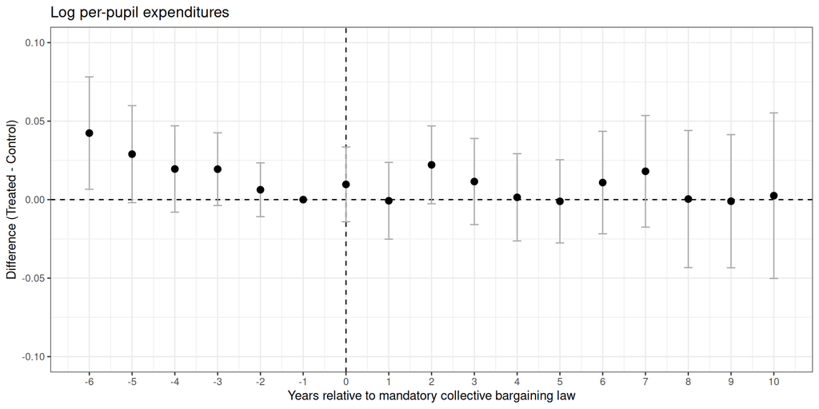

## Sun and Abraham (2021) Estimator

- One solution to the problem of **contamination bias** is to estimate the relative treatment time effects **separately** for each unique treatment timing group
  - Control group is the **never treated**
- Easy to implement in a single TWFE regression with **interactions** between cohort-indicators and relative-treatment time indicators.

  $$Y_{it} = \alpha_i + \delta_{t} + \sum_{g= 2}^T\sum_{l \neq -1} \tau_l^{(g)} (D^{(l)}_{it} \times \mathbf{1}(G_i = g)) + \epsilon_{it}$$
- Aggregate into **average** effects for each relative-treatment time by averaging over the cohorts with that particular relative treatment time.
- Implemented in the `fixest` R package using the `sunab()` syntax

## Example: Paglayan (2019, AJPS)

- Implementing the Sun and Abraham (2021) estimator

```r
### Per-pupil expenditure
# Code never-treated (NA) as Inf so sunab treats them as the control cohort
union_rep2_sa <- union_rep2
union_rep2_sa$YearCBrequired[is.na(union_rep2_sa$YearCBrequired)] <- Inf
dyn_reg_rep2_sa <- feols(lnppexpend ~ sunab(YearCBrequired, year, ref.p=-1) | year + State,
                            data=union_rep2_sa, cluster="State")
```

## Example: Paglayan (2019, AJPS)

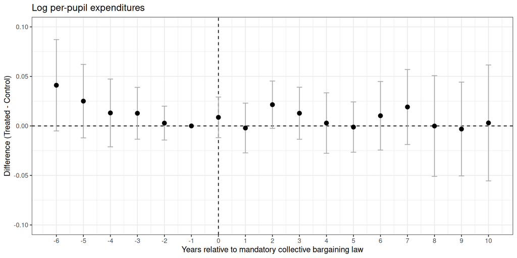

## Callaway and Sant’anna (2021) Estimator

- Rather than correcting the TWFE regression, directly estimate each **group-time** ATT via a simple 2x2 DiD
  - Compare each treated cohort $g$ at time $t$ to a **not-yet-treated** (or **never-treated**) control group
  - Use the period just before treatment ($g - 1$) as the baseline

    $$\widehat{ATT}_g(t) = \bar{Y}_{g, t} - \bar{Y}_{g, g-1} - \left(\sum_{g^\prime > t} \frac{N_{g^\prime}}{N^{(t)}}\bar{Y}_{g^\prime, t} - \sum_{g^\prime > t} \frac{N_{g^\prime}}{N^{(t)}}\bar{Y}_{g^\prime, g-1}\right)$$
  - where $N^{(t)} = \sum_{g^\prime > t} N_{g^\prime}$ is the total number of not-yet-treated units at time $t$
- Aggregate group-time ATTs into summary measures (overall ATT, calendar-time ATTs, relative-time ATTs, etc…)
  - Can add IPW + outcome model to allow for **conditional** parallel trends to hold
  - Easy to adjust for both **time-varying** and **time-invariant** confounders of parallel trends **(Caetano and Callaway, 2026)**
- Implemented in the `did` R package

## Example: Paglayan (2019, AJPS)

- Implementing the CS estimator in the `did` R package

```r
library(did)

dyn_reg_cs_1 <- att_gt(yname = "lnppexpend", tname="year", idname="Stateid",
                       gname="YearCBrequired", xformla = ~1,
                       base_period = "universal", control_group = "notyettreated",
                       cband = F, data=union_rep2)

dyn_reg_cs_1_agg <- aggte(dyn_reg_cs_1, type="dynamic")
```

## Example: Paglayan (2019, AJPS)

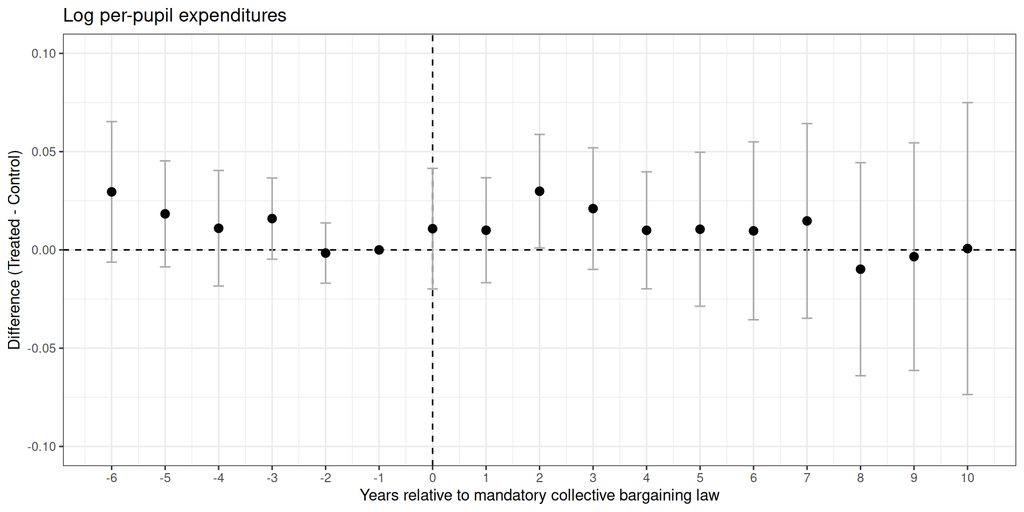

## Example: Paglayan (2019, AJPS)

- What happens if we implement CS with only the **never-treated** as the controls?
  - Equivalent to Sun and Abraham w/ reference group -1!

```r
library(did)
union_rep2$YearCBrequired[is.na(union_rep2$YearCBrequired)] <- 0
dyn_reg_cs_1 <- att_gt(yname = "lnppexpend", tname="year", idname="Stateid",
                       gname="YearCBrequired", xformla = ~1,
                       base_period = "universal", control_group = "nevertreated",
                       cband = F,
                        allow_unbalanced_panel = T, data=union_rep2)

dyn_reg_cs_1_agg <- aggte(dyn_reg_cs_1, type="dynamic", na.rm = T)
```

## Example: Paglayan (2019, AJPS)

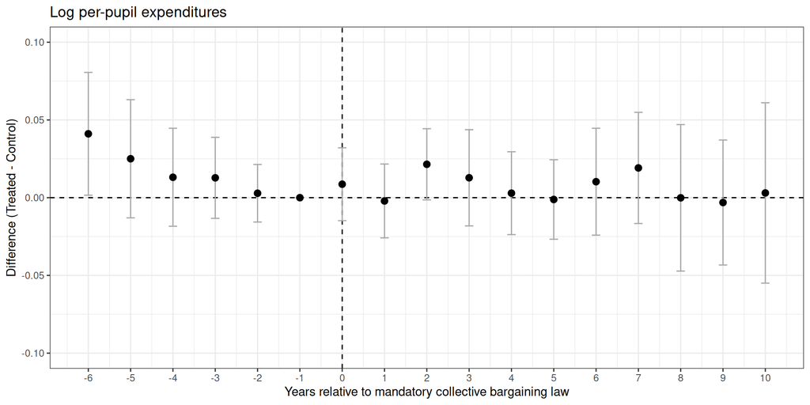

## Regression Imputation Estimator

- Alternative approach: **impute** the missing counterfactual $Y_{it}(\infty)$ for treated observations
  - Proposed by **Borusyak, Jaravel, and Spiess (2024)**; **Gardner (2022)**; **Liu, Wang, and Xu (2024)**
- **Step 1**: Fit unit and time fixed effects using **only** the untreated observations (control units + pre-treatment periods of treated units)

  $$Y_{it} = \alpha_i + \delta_t + \epsilon_{it}$$
- **Step 2**: For each treated unit predict

  $$\widehat{Y_{it}}(\infty) = \hat{\alpha_i} + \hat{\delta_t}$$
- **Step 3**: For each treated unit and time period, impute the treatment effect

  $$\hat{\tau}_{it} = Y_{it} - \widehat{Y_{it}}(\infty)$$
- **Step 4**: Aggregate the $\hat{\tau}_{it}$ into relevant quantities (e.g. relative time effects, overall average, etc…)
- Implemented in `fect` (among other packages)

## Regression Imputation Estimator

- The regression imputation estimator for a given **group-time ATT**
  $$ATT_{g}(t)$$
  can be expressed as an average over 2x2 differences-in-differences
  - Using all the pre-treatment periods as **baselines** ($t^\prime < g$)
  - And using all units that adopt treatment **after** $g$ ($g^\prime > g$)
- This creates a kind of **sequential structure** to the imputations for each post-treatment period
  - $ATT_{g}(g)$ is a simple average over DiDs…
  - …but $ATT_{g}(g+1)$ incorporates the estimates from $ATT_{g+1}(g+1)$…
  - …and so on…
- Units under **treatment** are used as “controls” with the model-imputed counterfactual acting as $Y_{it}$ for that period.

## Regression Imputation Estimator

[figure not shown]

Regression Imputation Group 3, Time 3

## Regression Imputation Estimator

[figure not shown]

Regression Imputation Group 4, Time 4

## Regression Imputation Estimator

[figure not shown]

Regression Imputation Group 3, Time 4

## Example: Paglayan (2019, AJPS)

- Implementing the regression imputation estimator using `fect`

```r
library(fect)
union_fect <- union
union_fect$CBrequired_SY <- as.numeric(union_fect$CBrequired_SY)
fect_fit <- fect(lnppexpend ~ CBrequired_SY, data = union_fect,
                 index = c("State", "year"), method = "fe",
                 force = "two-way", se = TRUE)
```

## Example: Paglayan (2019, AJPS)

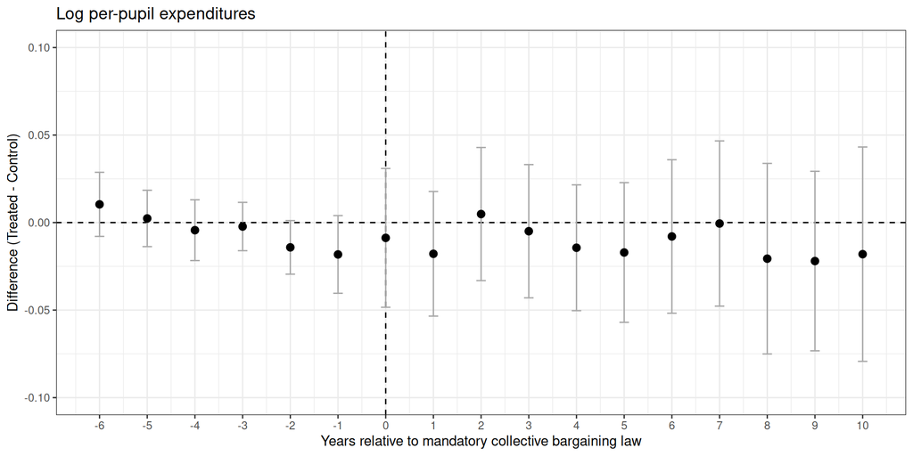

## New DiD is just old DiD

- All of the “heterogeneity-robust” difference-in-differences methods work in basically the same way
  - Estimate the **group-time ATTs** using only the 2x2 comparisons that are valid w/o additional homogeneity assumptions
- There are basically **two classes** of estimators
  - Either “fix the TWFE regression” (Sun and Abraham, regression imputation, ‘extended’ TWFE)
  - Or construct the “first-differences” regression (Callaway/Sant’anna)
- Implementations of these methods will differ on other options, but these are **researcher choices**
  - Which units are used as “controls”
  - Which periods act as the baseline
  - How to estimate standard errors (some form of asymptotic cluster SEs or bootstrap)

## Interpreting event study plots w/ “new” DiD estimators

- One downside of abandoning the traditional “event study plot” is that there are no clear convention for how to construct the plot of the treatment effects and the pre-treatment placebos usinig the **new** DiD estimators.
  - Common software implementations **don’t** generate figures that have the **same interpretation** as the dynamic TWFE **(Roth, 2026)**
- **Sun and Abraham (2021)** is the most direct equivalent to the original event study plot
  - All treatment effects and placebos are estimated from the same **held out** common baseline.
  - But remember that the **composition** of each relative treatment time **varies**
    - Late adopters don’t contribute to many of the treatment effects, early adopters don’t contribute to many of the placebos.

## Callaway/Sant’anna - Perils of the “varying” baseline

- One option in the Callaway-Sant’anna package is to compute placebos using a **varying** baseline.
  - This generates event study plots that are **asymmetric**
  - Post-treatment estimates all use $-1$ as the baseline time period
  - But the pre-treatment estimates are always relative to adjacent periods
    - “Short” DiDs only, not “long”
- Visually there is a **kink** even in the absence of any treatment effect!
  - Always us the **universal** baseline option!

```r
dyn_reg_cs_1 <- att_gt(yname = "lnppexpend", tname="year", idname="Stateid",
                       gname="YearCBrequired", xformla = ~1,
                       base_period = "varying", control_group = "notyettreated",
                       cband = F, data=union_rep2)

dyn_reg_cs_1_agg <- aggte(dyn_reg_cs_1, type="dynamic")
```

## Example of varying baseline (Paglayan, 2019)

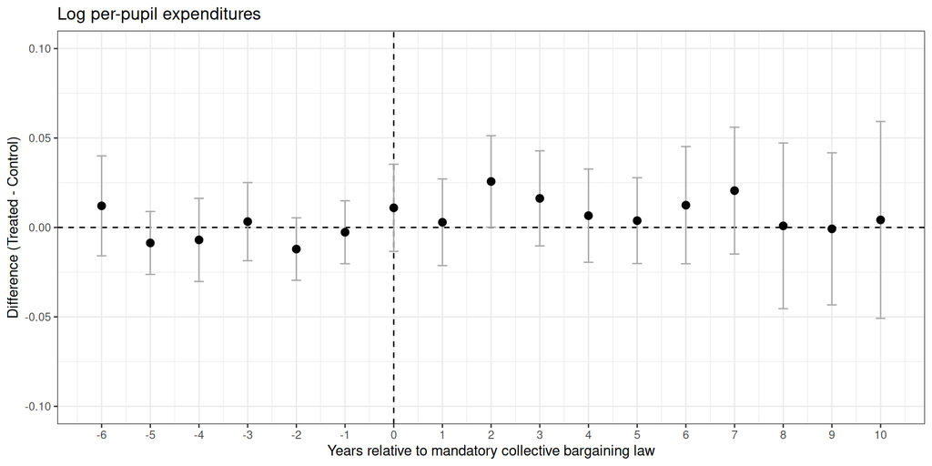

## Regression Imputation

- Regression imputation estimators exhibit an even more troubling problem
  - How do you construct a **placebo test** if **all** of the control observations are being used to estimate the treatment effects?
- **Trilemma** - You have to give up one of…
  1. Not using the same observations twice (imputing for units in the imputation regression)
  2. Using the same baselines as the treatment effect estimates
  3. Imputing for *all* of the pre-treatment periods
- What you give up depends on how you plan to use the pre-treatment placebo estimates.
  - But…you should definitely **avoid** imputing from the same regression as you used for the post-treatment observations (the default in `fect`)

## Example with the `fect` defaults

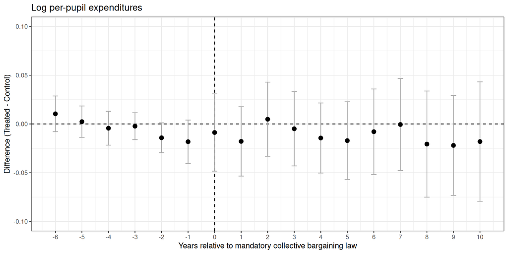

## Regression Imputation

- **Li and Strezhnev (2026)** show that the **in-sample** imputation approach suffers from two **biases** if you care about the **magnitudes** of the pre-treatment coefficients
  - **Attenuation bias** - Some of the component DiD comparisons are **zero by construction** since they re-use the same unit or period twice
  - **Contamination bias** - Under staggered adoption, placebo estimates for periods further away from treatment incorporate estimates for periods *closer* to treatment
- **Possible solution**
  - **“Double-leave-one-out”** approach - Estimate the placebo effects using **separate** models for each treatment timing group and time period.
  - Leave out all units that adopt treatment **prior** to the cohort of interest **and** the time period being imputed-for.

## In-sample imputation bias

- We can write the regression imputation estimator for a **pre-treatment** period as

$$\begin{align*}
\widehat{ATT}_{g}(t) &= \frac{1}{(g-1)N^{(t)}} \bigg[\sum_{g^\prime \ge g} \sum_{t^\prime = 1}^{g-1} N_{g^\prime}(\bar{Y}_{g,t} - \bar{Y}_{g,t^\prime} - \bar{Y}_{g^\prime, t} + \bar{Y}_{g^\prime, t^\prime}) + \\
&\hskip4em \sum_{g^\prime = t+1}^{g-1} \sum_{t^\prime = 1}^{g^\prime-1} N_{g^\prime}(\bar{Y}_{g,t} - \bar{Y}_{g,t^\prime} - \bar{Y}_{g^\prime, t} + \bar{Y}_{g^\prime, t^\prime}) + \\ &\hskip4em \sum_{g^\prime = t+1}^{g-1} \sum_{t^\prime = g^\prime}^{g-1} N_{g^\prime}(\bar{Y}_{g,t} - \bar{Y}_{g,t^\prime} - \bar{Y}_{g^\prime, t} + \hat{Y}_{g^\prime, t^\prime})\bigg]
\end{align*}$$

where $N^{(t)} = \sum_{g^\prime = t + 1}^G N_{g^\prime}$

## In-sample imputation bias

[figure not shown]

2x2 comparisons in in-sample TWFE imputation of placebo for group 3, time 1

## In-sample imputation: Non-staggered case

- Consider the simplest case: all treated units start treatment at time $g^*$. The expression for the **in-sample** imputation estimator simplifies to:

  $$\widehat{\text{ATT}_{is}(t)} = \frac{1}{(g^*-1)N}\bigg\{\sum_{t^\prime=1}^{g^*-1} N_{g^*}(\bar{Y}_{g^*, t} - \bar{Y}_{g^*,t} - \bar{Y}_{g^*, t^\prime} + \bar{Y}_{g^*, t^\prime}) + N_{\infty} (\bar{Y}_{g^*, t} - \bar{Y}_{\infty,t} - \bar{Y}_{g^*, t^\prime} + \bar{Y}_{\infty, t^\prime})\bigg\}$$
- It’s straightforward to see that the first part of that sum is always **zero** (since we are comparing $g^*$ to itself)
  - Additionally, any term where $t^\prime = t$ is also zero.
- Combined, the **in-sample** imputation estimator (compared to the “leave-one-out” estimator) exhibits an **attenuation** towards zero

  $$\widehat{\text{ATT}}_{\text{is}}(t) = \bigg(\frac{N_{G}}{N}\times\frac{g^*-2}{g^*-1}\bigg)\times\bigg(\widehat{\text{ATT}}_{\text{loo}}(t)\bigg)$$

## Application: Gazmararian (2025)

> Gazmararian, Alexander F. “Sources of partisan change: Evidence from the shale gas shock in American coal country.” The Journal of Politics 87, no. 2 (2025): 601-615.
- Examines whether the 2008 **shale gas shock** (fracking boom) shifted Republican presidential vote share in U.S. **coal counties**
  - Gas substitutes for coal, accelerating coal’s decline
  - Voters dependent on coal shift toward Republicans who promised looser environmental regulation
  - Treatment: coal county ($\geq$ 1% coal employment pre-2008) $\times$ post-2008
  - County-level analysis, presidential elections 1976-2020
- Original analysis uses `fect` with **in-sample** imputation (the default)
  - Pre-trends are **statistically distinguishable** from zero
  - But appear to be small - an **equivalence testing** approach concludes that the size of the violation is “negligible”

## Equivalence testing

- **Conventional** null hypothesis tests assume a null of **no** difference and reject in favor of an alternative that a difference exists

  $$H_0: \tau = 0; H_a: \tau \neq 0$$
- But with placebo tests, this is kind of **begging the question**
  - You are **assuming** what you set out to demonstrate (that a parallel trends violation is negligible)
  - Under low power settings, you might fail to reject under **large** violations!

## Equivalence testing

- **Equivalence testing** inverts this - assume a null that the true difference is greater than some “equivalence region” and an alternative that

  $$H_0: |\tau| \ge \epsilon; H_a: |\tau| < \epsilon$$
- Researcher selects the $\epsilon$ - what size of an effect is considered “negligible”
  - Existing recommendations mostly come from the literature on **balance checking** (Hartman and Hidalgo, 2018).
  - For assessing pre-trends, most intuitive to just benchmark against observed effects.
- Easy implementation - **Two One-Sided Test (TOST)** approach
  - Reject (in favor of a **negligible difference**) if the 90% confidence interval is entirely within the “equivalence region”

## Replication: In-sample vs. leave-one-out

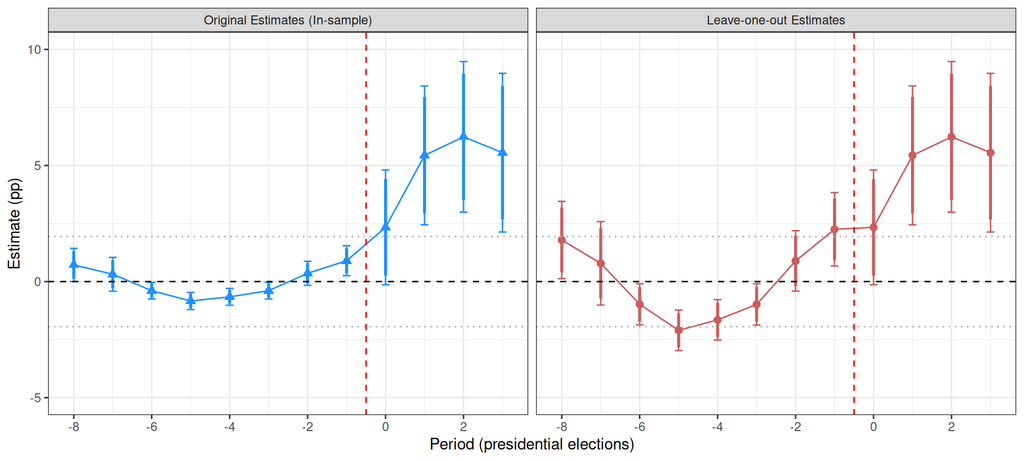

## Replication: Fixed baseline estimates

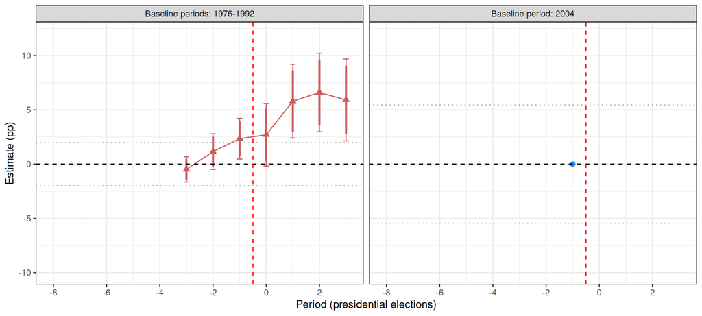

## HonestDiD: Partial identification

- An alternative approach to incorporating the actual pre-treatment placebos is to use them to **bound** the potential violation of parallel trends in the post-treatment period.
  - **Rambachan and Roth (2023)** propose a **partial identification** approach based on such a user specified bound
  - Develop an approach for construct **confidence sets** under this violation
- In our conventional **event-study** regression, we get estimates of…
  - $\beta_{l}^{\text{post}} = \tau_{l}^{\text{post}} + \delta_l^{\text{post}}$ - the treatment effects - a combination of the “true” effect and the parallel trends violation
  - $\beta_{l}^{\text{pre}} = \delta_l^{\text{pre}}$ - the pre-treatment “placebos” - these are **only** capturing the parallel trends violation
- We don’t want to assume $\delta = 0$.
  - Instead, we’ll relax that assumption by assuming $\delta \in \Delta$, some user-specified set of **restrictions**

## HonestDiD: Partial identification

- One popular approach recommended in **Rambachan and Roth (2023)** is to bound the **relative magnitudes**

  $$\Delta^{\text{RM}}(\bar{M}) = \bigg\{\delta: \forall l \ge 0, |\delta_{l+1} - \delta_{l}| \le \bar{M} \times \max_{s < 0} |\delta_{s - 1} - \delta_{s}|\bigg\}$$
- The **per-period** change in the violation of parallel trends in the **post-treatment** period is no more than $\bar{M}$ times the **largest** observed **per-period** violation in the pre-treatment period
  - $\bar{M} = 0$: Our **parallel trends** assumption holds
  - $\bar{M} = 1$: The violation in the post-treatment period is **as bad** as it is in the pre-treatment period.
- Construct a hypothesis test under the system of moment inequalities implied by the bound
  - Invert to obtain a **confidence set**
  - **Sensitivity analysis** - vary $\bar{M}$ and see at what level the results “break”

## HonestDiD: TWFE event study (Gazmararian, 2025)

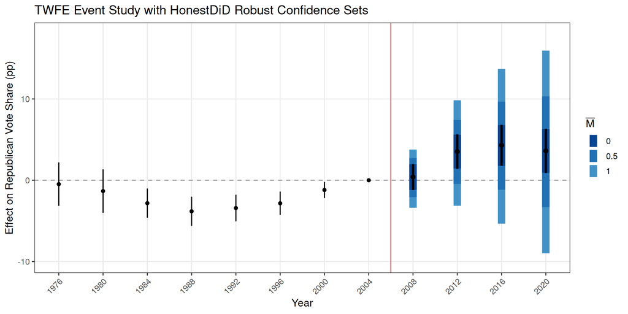

## Summary

- Diff-in-diff with two periods, two treatment groups
  - Parallel trends assumption - sensitive to transformations of the outcome (e.g. logs vs. levels)
  - Straightforward non-parametric estimator - can weight + use regression if parallel trends holds conditionally
- Diff-in-diff with multiple periods, two treatment groups
  - No changes! Everything is fine - TWFE still gives you a difference-in-difference under no effect homogeneity assumptions
  - Use pre-trends tests as a diagnostic, but be careful (w/ small samples, low power to violations)
- Diff-in-diff with staggered adoption
  - Can break down into a bunch of 2x2 DiDs for different treatment *groups* and *time* periods
  - But beware of naive 2-way fixed effects, both **static** and **dynamic** specifications - “bad” 2x2s if effects aren’t constant

# Next week

- Grab-bag of other topics on “time-series causal inference”
  - Diff-in-diff is **not** the only design when you have **time**
  - In fact, it’s arguably **not** even a “time-series” method
- When outcome in the past affects future treatment, DiD assumptions are violated!
  - We need a different design - back to selection-on-observables conditional on **lagged** outcome and treatment
  - Identification under “sequential ignorability” - lagged DV/IV regressions.
- “Synthetic control” designs - reweight controls to match treated units on lagged outcomes.
- Additional bit of discussion on what “fixed effects” accomplish and how to think about them
  - Fixed effects are a form of **de-meaning** - equivalent to controlling for **averages** of the outcome (the “Mundlak” device)